# P5 Predicting persons of interest in Enron dataset

```python
#!/usr/bin/python

import sys
import pickle
import tester
sys.path.append("../tools/")

%matplotlib inline

from feature_format import featureFormat, targetFeatureSplit
from tester import dump_classifier_and_data

from ggplot import *
import pandas as pd
import numpy as np
```

## Task 1: Select what features you'll use

Explore the dataset a bit and see what features there are.

```python
### features_list is a list of strings, each of which is a feature name.
### The first feature must be "poi".
features_list = ['poi','salary'] # You will need to use more features

# financial features: ['salary', 'deferral_payments', 'total_payments', 'loan_advances', 'bonus', 'restricted_stock_deferred', 'deferred_income', 'total_stock_value', 'expenses', 'exercised_stock_options', 'other', 'long_term_incentive', 'restricted_stock', 'director_fees'] (all units are in US dollars)
# email features: ['to_messages', 'email_address', 'from_poi_to_this_person', 'from_messages', 'from_this_person_to_poi', 'shared_receipt_with_poi'] (units are generally number of emails messages; notable exception is ‘email_address’, which is a text string)
# POI label: [‘poi’] (boolean, represented as integer)

### Load the dictionary containing the dataset
with open("final_project_dataset.pkl", "r") as data_file:
    data_dict = pickle.load(data_file)

# create pandas data frame from data dictionary
data_df = pd.DataFrame.from_dict(data_dict, orient="index")
```

```python
# number of individuals and features
data_df.shape
```

```
(146, 21)
```

```python
#column names
data_df.columns.values
```

```
array(['salary', 'to_messages', 'deferral_payments', 'total_payments',
       'exercised_stock_options', 'bonus', 'restricted_stock',
       'shared_receipt_with_poi', 'restricted_stock_deferred',
       'total_stock_value', 'expenses', 'loan_advances', 'from_messages',
       'other', 'from_this_person_to_poi', 'poi', 'director_fees',
       'deferred_income', 'long_term_incentive', 'email_address',
       'from_poi_to_this_person'], dtype=object)
```

```python
# number of POI
pd.value_counts(data_df['poi'])
```

```
False    128
True      18
dtype: int64
```

```python
# number of missing values for every column

data_df.apply(lambda x : x == "NaN", axis = 1).sum()
```

```
salary                        51
to_messages                   60
deferral_payments            107
total_payments                21
exercised_stock_options       44
bonus                         64
restricted_stock              36
shared_receipt_with_poi       60
restricted_stock_deferred    128
total_stock_value             20
expenses                      51
loan_advances                142
from_messages                 60
other                         53
from_this_person_to_poi       60
poi                            0
director_fees                129
deferred_income               97
long_term_incentive           80
email_address                 35
from_poi_to_this_person       60
dtype: int64
```

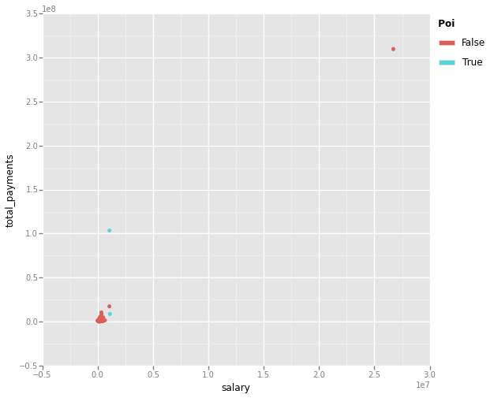

```python
ggplot(data_df, aes(x='salary', y='total_payments', color = 'poi')) + geom_point()
```

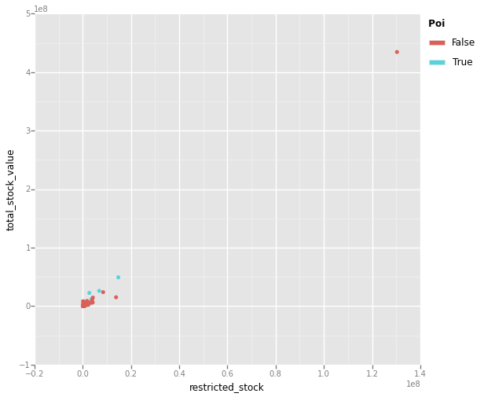

```python
ggplot(data_df, aes(x='restricted_stock', y='total_stock_value', color = 'poi')) + geom_point()
```

## Task 2: Remove outliers

Identify and remove outliers in this dataset. Ended up removing two points (TOTAL and LOCKHART EUGENE E). TOTAL is not an actual individual and Lockhart has no data.

```python
data_df.apply(lambda x : x == "NaN", axis = 1).sum(1).sort(inplace = False, ascending= False)[0:10]
```

```
LOCKHART EUGENE E                20
GRAMM WENDY L                    18
WROBEL BRUCE                     18
WHALEY DAVID A                   18
THE TRAVEL AGENCY IN THE PARK    18
WAKEHAM JOHN                     17
WODRASKA JOHN                    17
CLINE KENNETH W                  17
GILLIS JOHN                      17
SCRIMSHAW MATTHEW                17
dtype: int64
```

```python
data_dict.pop("TOTAL", 0)
data_dict.pop("LOCKHART EUGENE E", 0)

data_df.drop(['TOTAL', 'LOCKHART EUGENE E'], inplace=True)
```

## Task 3: Create new feature(s)

I created 3 new features. Two of the features are scaling email to total emails received/sent while the last feature is around scaling compensation.

```python
for key, value in data_dict.iteritems():
    # fraction from this person to poi
    if value['from_this_person_to_poi'] != "NaN" and value['to_messages'] != "NaN":
        value['fraction_from_this_person_to_poi'] = value['from_this_person_to_poi'] / float(value['to_messages'])
    else:
        value['fraction_from_this_person_to_poi'] = "NaN"
    # fraction from poi to this person
    if value['from_poi_to_this_person'] != "NaN" and value['from_messages'] != "NaN":
        value['fraction_from_poi_to_this_person'] = value['from_poi_to_this_person'] / float(value['from_messages'])
    else:
        value['fraction_from_poi_to_this_person'] = "NaN"
    # fraction total compensation from stocks (assuming you have salary)
    if value['salary'] != "NaN" and value['total_payments'] != "NaN" and value['total_stock_value'] != "NaN":
        value['fraction_compensation_stock'] = value['total_stock_value'] / float(value['total_payments'] + value['total_stock_value'])
    else:
        value['fraction_compensation_stock'] = "NaN"
```

```python
# create feature list of everything
features_list = ['poi', 'salary', 'deferral_payments', 'total_payments',
                 'loan_advances', 'bonus', 'restricted_stock_deferred',
                 'deferred_income', 'total_stock_value', 'expenses',
                 'exercised_stock_options', 'other', 'long_term_incentive',
                 'restricted_stock', 'director_fees', 'to_messages',
                 'from_poi_to_this_person', 'from_messages', 'from_this_person_to_poi',
                 'shared_receipt_with_poi', 'fraction_from_this_person_to_poi',
                 'fraction_from_poi_to_this_person', 'fraction_compensation_stock']

# features_list = ['poi',
#                  'shared_receipt_with_poi', 'fraction_from_this_person_to_poi',
#                  'fraction_from_poi_to_this_person', 'fraction_compensation_stock']
# features_list = ['poi','salary']
```

```python
### Store to my_dataset for easy export below.
my_dataset = data_dict

### Extract features and labels from dataset for local testing
data = featureFormat(my_dataset, features_list, sort_keys = True) #, remove_NaN = False)
labels, features = targetFeatureSplit(data)
```

## Task 4: Try a varity of classifiers

Please name your classifier clf for easy export below. Note that if you want to do PCA or other multi-stage operations, you'll need to use Pipelines. For more info: http://scikit-learn.org/stable/modules/pipeline.html

```python
from sklearn.preprocessing import scale
features_scaled = scale(features)

from sklearn.feature_selection import SelectKBest
clf = SelectKBest(k = 5) # use grid search later to optimize
features_kbest = clf.fit_transform(features_scaled, labels)
```

```python
features_kbest_output = zip(features_list[1:], clf.scores_, clf.get_support())
features_kbest_output.sort(key=lambda value:value[1], reverse=True)
features_kbest_output
```

```
[('exercised_stock_options', 25.097541528735494, True),
 ('total_stock_value', 24.467654047526391, True),
 ('bonus', 21.060001707536589, True),
 ('salary', 18.575703268041782, True),
 ('deferred_income', 11.595547659730601, True),
 ('long_term_incentive', 10.072454529369448, False),
 ('restricted_stock', 9.3467007910514894, False),
 ('total_payments', 8.8667215371077699, False),
 ('shared_receipt_with_poi', 8.7464855321290784, False),
 ('loan_advances', 7.2427303965360244, False),
 ('expenses', 6.2342011405067428, False),
 ('fraction_compensation_stock', 5.6035508898354731, False),
 ('from_poi_to_this_person', 5.3449415231473365, False),
 ('fraction_from_poi_to_this_person', 5.2096502205817989, False),
 ('other', 4.2049708583014178, False),
 ('fraction_from_this_person_to_poi', 4.1690838152893868, False),
 ('from_this_person_to_poi', 2.4265081272428737, False),
 ('director_fees', 2.1076559432760891, False),
 ('to_messages', 1.6988243485808472, False),
 ('deferral_payments', 0.21705893033950885, False),
 ('from_messages', 0.1641644982342865, False),
 ('restricted_stock_deferred', 0.0649843117237109, False)]
```

```
Feature ranking:
1. exercised_stock_options (0.092788)
2. total_stock_value (0.086202)
3. deferred_income (0.074527)
4. bonus (0.069562)
5. other (0.060939)
6. fraction_from_poi_to_this_person (0.060170)
7. expenses (0.057660)
8. restricted_stock (0.053051)
9. fraction_from_this_person_to_poi (0.051843)
10. fraction_compensation_stock (0.047923)
11. from_poi_to_this_person (0.046903)
12. shared_receipt_with_poi (0.044447)
13. long_term_incentive (0.043561)
14. salary (0.042203)
15. from_this_person_to_poi (0.040943)
16. total_payments (0.039861)
17. to_messages (0.028893)
18. from_messages (0.025266)
19. deferral_payments (0.018779)
20. loan_advances (0.007654)
21. restricted_stock_deferred (0.005720)
22. director_fees (0.001106)
```

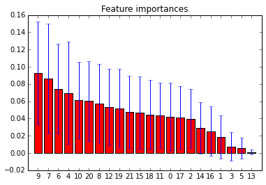

```python
import matplotlib.pyplot as plt

from sklearn.ensemble import ExtraTreesClassifier

# Build a forest and compute the feature importances
forest = ExtraTreesClassifier(n_estimators=250,
                              random_state=0)

X = np.array(features) # needed for shape
# y = np.array(labels)
forest.fit(features, labels)
importances = forest.feature_importances_
std = np.std([tree.feature_importances_ for tree in forest.estimators_],
             axis=0)
indices = np.argsort(importances)[::-1]

# Print the feature ranking
print("Feature ranking:")

for f in range(X.shape[1]):
    print("%d. %s (%f)" % (f + 1, features_list[indices[f]+1], importances[indices[f]]))

# Plot the feature importances of the forest
plt.figure()
plt.title("Feature importances")
plt.bar(range(X.shape[1]), importances[indices],
       color="r", yerr=std[indices], align="center")
plt.xticks(range(X.shape[1]), indices)
plt.xlim([-1, X.shape[1]])
plt.show()
```